# Questions

> **Note: To help you check your responses, I’ve supplied some rough answers. You should write the whole answers on the exam.**

## Question 1

An advertising firm is interested in studying the effect of four types of sales advertisements (A, B, C and D) on the sales amount of a certain product in a city. The stores in the city can be divided into three groups as small scale, middle scale and large scale accordingly to the size of their sales amount. Under each group, a random ordering of four types of sales advertisements was exhibited in the selected four stores of same size. Sales amounts for a week are shown in the table below.

```
   advertisement_type  store sales
1                   A  Small    24
2                   A Middle    40
3                   A  Large    41
4                   B  Small    28
5                   B Middle    48
6                   B  Large    52
7                   C  Small    20
8                   C Middle    32
9                   C  Large    35
10                  D  Small    26
11                  D Middle    50
12                  D  Large    55
```

**Part 1**

These data were given to two students separately and asked to construct the ANOVA table to analyze. The results obtained by them are shown below. Some values were missing in each ANOVA table and marked with a blank space “…”.

Complete each ANOVA table by completing the missing values.

*Results of the first student*

| Source | DF | SS | MS | F | P |
| --- | --- | --- | --- | --- | --- |
| Advertisement type | … | … | … | … | 0.432 |
| Error | … | 1119.33 | … |  |  |
| Total | … | 1548.91 |  |  |  |

*Results of the second student*

[output not shown]

**Part 2**

State the differences between the two approaches these students had applied.

**Part 3**

One student has obtained the following graph. Comment on it.

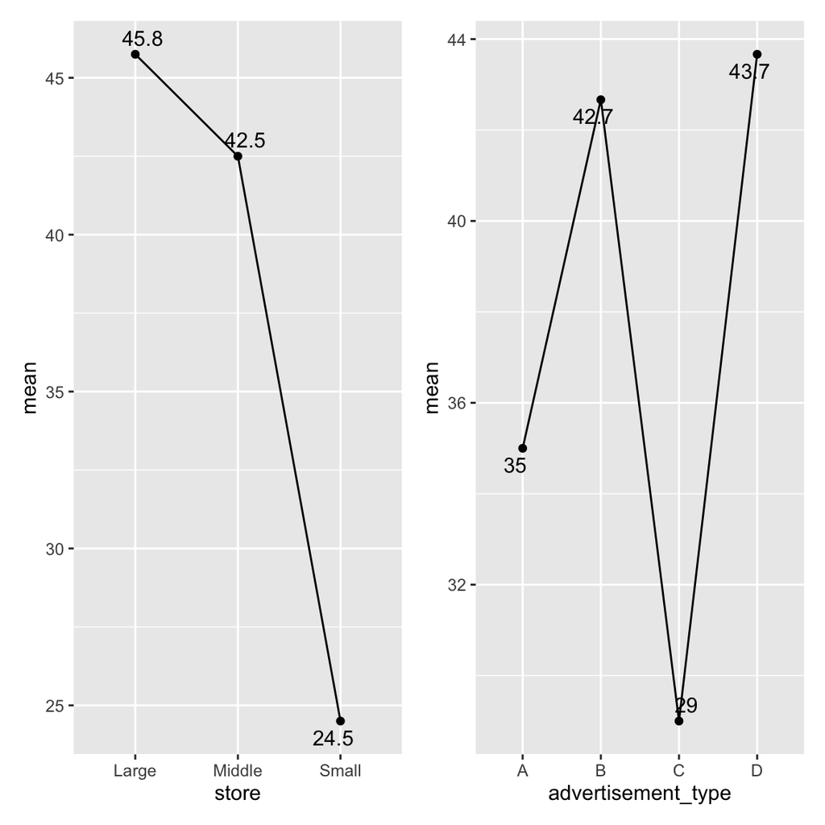

**Part 4**

If you are to perform the same analysis, which approach would you apply? Justify your answer.

**Part 5**

Write the effect model for the selected approach and define all the terms of it.

**Part 6**

Write the hypotheses of the selected model and state your decisions at 5% level of significance. Interpret your results. (No need to do multiple comparisons.)

# Q1-1: Answer (Help)

**First student**

```
Analysis of Variance Table

Response: sales
                   Df  Sum Sq Mean Sq F value Pr(>F)
advertisement_type  3  429.58  143.19  1.0234  0.432
Residuals           8 1119.33  139.92
```

**Second student**

```
Analysis of Variance Table

Response: sales
                   Df  Sum Sq Mean Sq F value   Pr(>F)
advertisement_type  3  429.58  143.19  12.073 0.005935 **
store               2 1048.17  524.08  44.185 0.000257 ***
Residuals           6   71.17   11.86
---
Signif. codes:  0 '***' 0.001 '**' 0.01 '*' 0.05 '.' 0.1 ' ' 1
```

# Q1-2: Answer (Help)

First student used CRD.

Second student used RCBD.

# Q1-3: Answer (Help)

Your turn, interpret!

# Q1-4: Answer (Help)

RCBD

Reason: Your turn, explain!

# Q1-5: Answer (Help)

See lecture materials at https://smart-doe.netlify.app/slides/l6_doe#20

# Q1-6: Answer (Help)

See lecture materials at https://smart-doe.netlify.app/slides/l6_doe#25

Use effect model format.

# Question 2

What is the main advantage of a randomized complete block design over a completely randomized design?

# Question 2: Answer (Help)

Refer to teaching materials

# Question 3

What are the advantages of factorial design?

# Question 3: Answer (Help)

Refer to teaching materials

# Question 4

What is a factorial design?

# Question 4: Answer (Help)

In a factorial design, multiple independent variables are tested.

Refer to teaching materials for more information.

# Question 5

```
   temperature material strength
1          100        1      581
2          100        1      567
3          100        1      572
4          100        2      555
5          100        2      530
6          100        2      580
7          100        3      556
8          100        3      585
9          100        3      600
10         125        1     1090
11         125        1     1087
12         125        1     1085
13         125        2     1069
14         125        2     1034
15         125        2      999
16         125        3     1046
17         125        3     1054
18         125        3     1070
19         150        1     1392
20         150        1     1380
21         150        1     1388
22         150        2     1330
23         150        2     1315
24         150        2     1300
25         150        3      887
26         150        3      905
27         150        3      890
```

The following summary statistics are obtained

```
# A tibble: 3 × 2
  temperature  mean
  <fct>       <dbl>
1 100          570.
2 125         1059.
3 150         1199.
```

```
# A tibble: 3 × 2
  material  mean
  <fct>    <dbl>
1 1        1016.
2 2         968
3 3         844.
```

```
# A tibble: 9 × 3
# Groups:   material [3]
  material temperature  mean
  <fct>    <fct>       <dbl>
1 1        100          573.
2 1        125         1087.
3 1        150         1387.
4 2        100          555
5 2        125         1034
6 2        150         1315
7 3        100          580.
8 3        125         1057.
9 3        150          894
```

```
      mean
1 942.4815
```

**Part 1**

**Part 2**

Draw graph of mean responses at each treatment combination and comment on it.

# Question 5 - Part 1 Answer (Help)

Based on the given information you should be able to construct ANOVA table.

Furthermore, you should be able to compute $y_{..}$, $y_{.jk}$, etc.

Using the following information you can complete the ANOVA table.

|  | Df | Sum Sq | Mean Sq | F value | Pr(>F) |
| --- | --- | --- | --- | --- | --- |
| temperature | 2 | 1964718.296 | 982359.1481 | 3036.4851 | 0 |
| material | 2 | 142091.185 | 71045.5926 | 219.6029 | 0 |
| temperature:material | 4 | 288331.926 | 72082.9815 | 222.8094 | 0 |
| Residuals | 18 | 5823.333 | 323.5185 | NA | NA |

# Question 5 - Part 2 Answer (Help)

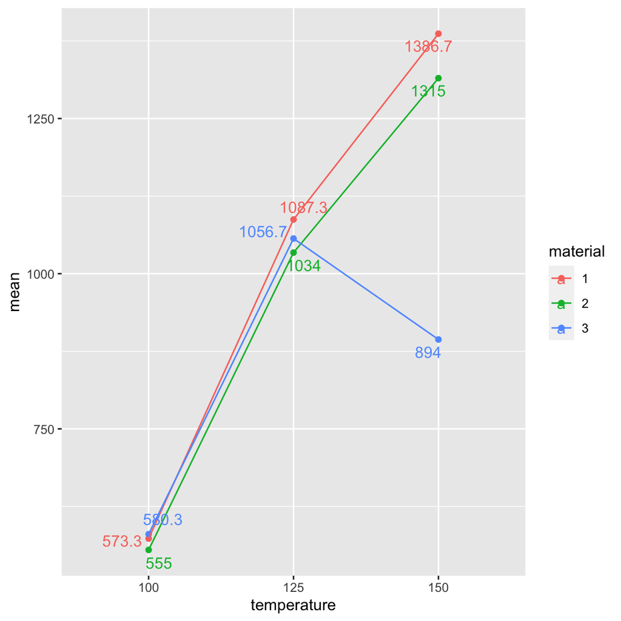

# Question 6

**MCQ**

Why would you use the Tukey multiple comparison?

1. To test for normality
2. To test for homogeneity of variance
3. To test for differences in pairwise means
4. To test independence of errors

# Question 6: Answer

3. To test for differences in pairwise means

# Question 7

The following Tukey multiple comparisons results are obtained for data in Question 5. Which combination(s) of treatments would you recommend? State all.

```
  Tukey multiple comparisons of means
    95% family-wise confidence level

Fit: aov(formula = strength ~ material * temperature, data = df)

$material
          diff       lwr        upr    p adj
2-1  -47.77778  -69.4175  -26.13805 6.82e-05
3-1 -172.11111 -193.7508 -150.47139 0.00e+00
3-2 -124.33333 -145.9731 -102.69361 0.00e+00

$temperature
            diff      lwr      upr p adj
125-100 489.7778 468.1381 511.4175     0
150-100 629.0000 607.3603 650.6397     0
150-125 139.2222 117.5825 160.8619     0

$`material:temperature`
                  diff        lwr         upr     p adj
2:100-1:100  -18.33333  -69.79110   33.124435 0.9339075
3:100-1:100    7.00000  -44.45777   58.457768 0.9998856
1:125-1:100  514.00000  462.54223  565.457768 0.0000000
2:125-1:100  460.66667  409.20890  512.124435 0.0000000
3:125-1:100  483.33333  431.87557  534.791101 0.0000000
1:150-1:100  813.33333  761.87557  864.791101 0.0000000
2:150-1:100  741.66667  690.20890  793.124435 0.0000000
3:150-1:100  320.66667  269.20890  372.124435 0.0000000
3:100-2:100   25.33333  -26.12443   76.791101 0.7253054
1:125-2:100  532.33333  480.87557  583.791101 0.0000000
2:125-2:100  479.00000  427.54223  530.457768 0.0000000
3:125-2:100  501.66667  450.20890  553.124435 0.0000000
1:150-2:100  831.66667  780.20890  883.124435 0.0000000
2:150-2:100  760.00000  708.54223  811.457768 0.0000000
3:150-2:100  339.00000  287.54223  390.457768 0.0000000
1:125-3:100  507.00000  455.54223  558.457768 0.0000000
2:125-3:100  453.66667  402.20890  505.124435 0.0000000
3:125-3:100  476.33333  424.87557  527.791101 0.0000000
1:150-3:100  806.33333  754.87557  857.791101 0.0000000
2:150-3:100  734.66667  683.20890  786.124435 0.0000000
3:150-3:100  313.66667  262.20890  365.124435 0.0000000
2:125-1:125  -53.33333 -104.79110   -1.875565 0.0388843
3:125-1:125  -30.66667  -82.12443   20.791101 0.5092032
1:150-1:125  299.33333  247.87557  350.791101 0.0000000
2:150-1:125  227.66667  176.20890  279.124435 0.0000000
3:150-1:125 -193.33333 -244.79110 -141.875565 0.0000000
3:125-2:125   22.66667  -28.79110   74.124435 0.8213687
1:150-2:125  352.66667  301.20890  404.124435 0.0000000
2:150-2:125  281.00000  229.54223  332.457768 0.0000000
3:150-2:125 -140.00000 -191.45777  -88.542232 0.0000006
1:150-3:125  330.00000  278.54223  381.457768 0.0000000
2:150-3:125  258.33333  206.87557  309.791101 0.0000000
3:150-3:125 -162.66667 -214.12443 -111.208899 0.0000001
2:150-1:150  -71.66667 -123.12443  -20.208899 0.0030058
3:150-1:150 -492.66667 -544.12443 -441.208899 0.0000000
3:150-2:150 -421.00000 -472.45777 -369.542232 0.0000000
```

# Question 7: Answer (Help)

Hint: If interaction is significant, you should compare all `material::temperature` cell means to determine which ones differ significantly.